# Statistics for Data Science with `R`

# Other Methods for Models

## Introduction

Statistical literature on prediction/modeling techniques is growing very quickly. New techniques applied to data-mining and to business intelligence projects appear every day, and new developments allow the researcher to obtain even more precise predictions. Main aim of this chapter is to introduce very briefly some options that are (in our beliefs) the basis of more recent advancements in predictive/modeling analytics.

Three analytical options will be introduced in this chapter:

- Neural Networks
- Classification/Regression Trees
- GAM models

A couple of examples will allow us to understand the main characteristics of each technique, and within each example a comparison between techniques will be performed.

## Analysis examples

Let us clean our workspace

```r
rm(list=ls())
```

and load libraries

```r
require(qdata)
require(nnet)
require(rpart)
require(mgcv)
require(MASS)
require(ggplot2)
```

## Example: Titanic

### Data description

This example uses the true data from surviving to Titanic wreck.  
The aim of study is to find a prediction model to assess the probability of die for each passenger based on its `Age`, `Gender`, and `Class` of accomodation.

Another useful information that will be extracted is if a causal relation exists between the above explicative variables and the probability of die.

### Data loading

```r
data(titanic)
head(titanic)
```

```
## # A tibble: 6 x 4
##    Class Gender   Age   Status
##   <fctr> <fctr> <int>   <fctr>
## 1  Coach Female    20 Survived
## 2  Coach Female    21 Survived
## 3  Coach Female    26 Survived
## 4  Coach Female    26     Died
## 5  Coach Female    36 Survived
## 6  Coach Female    41 Survived
```

```r
str(titanic)
```

```
## Classes 'tbl_df', 'tbl' and 'data.frame':    2201 obs. of  4 variables:
##  $ Class : Factor w/ 2 levels "Coach","First": 1 1 1 1 1 1 1 1 1 1 ...
##  $ Gender: Factor w/ 2 levels "Female","Male": 1 1 1 1 1 1 1 1 1 1 ...
##  $ Age   : int  20 21 26 26 36 41 41 45 45 48 ...
##  $ Status: Factor w/ 2 levels "Died","Survived": 2 2 2 1 2 2 2 2 1 2 ...
```

### Descriptives

Some tables could help in describing the relations between die probability and explicative variables

```r
(tb1 <- table(titanic$Status,titanic$Class))
```

```
##
##            Coach First
##   Died      1368   122
##   Survived   508   203
```

```r
round(prop.table(tb1,margin=2)*100,2)
```

```
##
##            Coach First
##   Died     72.92 37.54
##   Survived 27.08 62.46
```

```r
(tb2 <- table(titanic$Status,titanic$Gender))
```

```
##
##            Female Male
##   Died        126 1364
##   Survived    344  367
```

```r
round(prop.table(tb2,margin=2)*100,2)
```

```
##
##            Female  Male
##   Died      26.81 78.80
##   Survived  73.19 21.20
```

```r
(tb3 <- table(titanic$Status,titanic$Class,titanic$Gender))
```

```
## , ,  = Female
##
##
##            Coach First
##   Died       122     4
##   Survived   203   141
##
## , ,  = Male
##
##
##            Coach First
##   Died      1246   118
##   Survived   305    62
```

```r
round(prop.table(tb3,margin=c(2,3))*100,2)
```

```
## , ,  = Female
##
##
##            Coach First
##   Died     37.54  2.76
##   Survived 62.46 97.24
##
## , ,  = Male
##
##
##            Coach First
##   Died     80.34 65.56
##   Survived 19.66 34.44
```

The above tables show counts and percentages of died and survived for each combination of Sex and Class factors. Some relations appear, but its interpretation is not really simple.

The following graph shows if some relations exist between `Status` and `Age`:

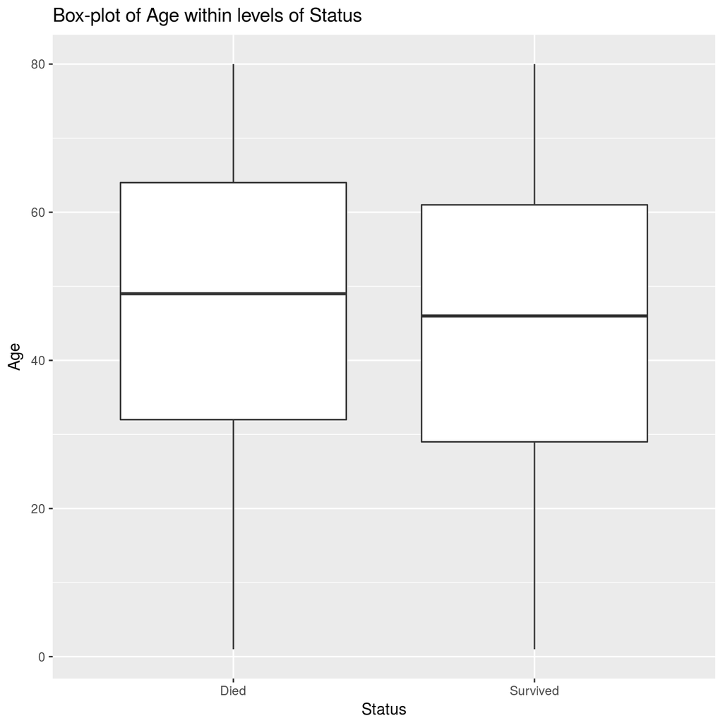

Box-plot of Age within levels of Status

```r
(ggp <- ggplot(data=titanic, mapping=aes(x=Status, y=Age)) +
  geom_boxplot()+ ggtitle("Box-plot of Age within levels of Status"))
```

Apparently, a slightly lower age is in survived passengers.

### Inference and models

Let us start with a **logistic model**. Since from table above all main effects and the interaction between `Class` and `Gender` appear as significant, the initial model will use these effects. Note that in this case the probability estimated from the model is the probability to survive, not the probability to die.

```r
fm1 <- glm(Status ~ Class+Gender+Class:Gender+Age, data = titanic, family = binomial)
summary(fm1)
```

```
##
## Call:
## glm(formula = Status ~ Class + Gender + Class:Gender + Age, family = binomial,
##     data = titanic)
##
## Deviance Residuals:
##     Min       1Q   Median       3Q      Max
## -2.7811  -0.6989  -0.6261   0.8743   1.9286
##
## Coefficients:
##                        Estimate Std. Error z value Pr(>|z|)
## (Intercept)            0.883056   0.165768   5.327 9.98e-08 ***
## ClassFirst             3.115273   0.520533   5.985 2.17e-09 ***
## GenderMale            -1.897564   0.131599 -14.419  < 2e-16 ***
## Age                   -0.008450   0.002673  -3.162  0.00157 **
## ClassFirst:GenderMale -2.345046   0.547416  -4.284 1.84e-05 ***
## ---
## Signif. codes:  0 '***' 0.001 '**' 0.01 '*' 0.05 '.' 0.1 ' ' 1
##
## (Dispersion parameter for binomial family taken to be 1)
##
##     Null deviance: 2769.5  on 2200  degrees of freedom
## Residual deviance: 2226.3  on 2196  degrees of freedom
## AIC: 2236.3
##
## Number of Fisher Scoring iterations: 6
```

All the effects appear significant using Wald test. Passengers in first class, female and younger passengers have a greater probability to survive. The greater probability to survive for first class passengers, is indeed reduced for male passengers. In other words, the `First` class passengers have a greater probability to survive, but the increased probability for `Male` is lesser than for `Female` passengers.  
Now we would like to test if the interaction between `Class` and `Age` may help to explain the probability to survive:

```r
fm2 <- glm(Status ~ Class+Gender+Class:Gender+Age+Class:Age, data = titanic, family = binomial)
summary(fm2)
```

```
##
## Call:
## glm(formula = Status ~ Class + Gender + Class:Gender + Age +
##     Class:Age, family = binomial, data = titanic)
##
## Deviance Residuals:
##     Min       1Q   Median       3Q      Max
## -2.7641  -0.6997  -0.6253   0.8723   1.9313
##
## Coefficients:
##                        Estimate Std. Error z value Pr(>|z|)
## (Intercept)            0.891032   0.171246   5.203 1.96e-07 ***
## ClassFirst             3.033822   0.677964   4.475 7.64e-06 ***
## GenderMale            -1.897421   0.131616 -14.416  < 2e-16 ***
## Age                   -0.008629   0.002839  -3.040  0.00237 **
## ClassFirst:GenderMale -2.337033   0.548790  -4.259 2.06e-05 ***
## ClassFirst:Age         0.001572   0.008419   0.187  0.85185
## ---
## Signif. codes:  0 '***' 0.001 '**' 0.01 '*' 0.05 '.' 0.1 ' ' 1
##
## (Dispersion parameter for binomial family taken to be 1)
##
##     Null deviance: 2769.5  on 2200  degrees of freedom
## Residual deviance: 2226.2  on 2195  degrees of freedom
## AIC: 2238.2
##
## Number of Fisher Scoring iterations: 6
```

```r
anova(fm1,fm2,test="LRT")
```

```
## Analysis of Deviance Table
##
## Model 1: Status ~ Class + Gender + Class:Gender + Age
## Model 2: Status ~ Class + Gender + Class:Gender + Age + Class:Age
##   Resid. Df Resid. Dev Df Deviance Pr(>Chi)
## 1      2196     2226.2
## 2      2195     2226.2  1 0.034842   0.8519
```

Either Wald or Likelihood-ratio tests confirm that the above interaction seem to not explain the variability in survival. Now we would like to test if the `Gender` by `Age` interaction is significant.

```r
fm3 <- glm(Status ~ Class+Gender+Class:Gender+Age+Gender:Age, data = titanic, family = binomial)
summary(fm3)
```

```
##
## Call:
## glm(formula = Status ~ Class + Gender + Class:Gender + Age +
##     Gender:Age, family = binomial, data = titanic)
##
## Deviance Residuals:
##     Min       1Q   Median       3Q      Max
## -2.6944  -0.7081  -0.6163   0.9558   1.9623
##
## Coefficients:
##                        Estimate Std. Error z value Pr(>|z|)
## (Intercept)            0.563915   0.266683   2.115   0.0345 *
## ClassFirst             3.061456   0.521118   5.875 4.23e-09 ***
## GenderMale            -1.477905   0.306929  -4.815 1.47e-06 ***
## Age                   -0.001248   0.005482  -0.228   0.8200
## ClassFirst:GenderMale -2.288152   0.548204  -4.174 2.99e-05 ***
## GenderMale:Age        -0.009423   0.006278  -1.501   0.1334
## ---
## Signif. codes:  0 '***' 0.001 '**' 0.01 '*' 0.05 '.' 0.1 ' ' 1
##
## (Dispersion parameter for binomial family taken to be 1)
##
##     Null deviance: 2769.5  on 2200  degrees of freedom
## Residual deviance: 2224.0  on 2195  degrees of freedom
## AIC: 2236
##
## Number of Fisher Scoring iterations: 6
```

```r
anova(fm1,fm3,test="LRT")
```

```
## Analysis of Deviance Table
##
## Model 1: Status ~ Class + Gender + Class:Gender + Age
## Model 2: Status ~ Class + Gender + Class:Gender + Age + Gender:Age
##   Resid. Df Resid. Dev Df Deviance Pr(>Chi)
## 1      2196     2226.2
## 2      2195     2224.0  1   2.2459    0.134
```

This interaction is not significant too.

Now the calculation of predictions through th “best” model are calculated. These predictions will be used to make comparisons with other techniques.

```r
predglm <- predict(fm1,type="response")
```

### Neural networks

Neural networks can be considered a type of nonlinear regression that takes a set of inputs (explanatory variables), transforms and weights these within a set of hidden units and hidden layers to produce a set of outputs or predictions (that are also transformed).

Next figure is an example of a feed forward neural network consisting of four inputs, a hidden layer that contains three units and an output layer that contains two outputs.

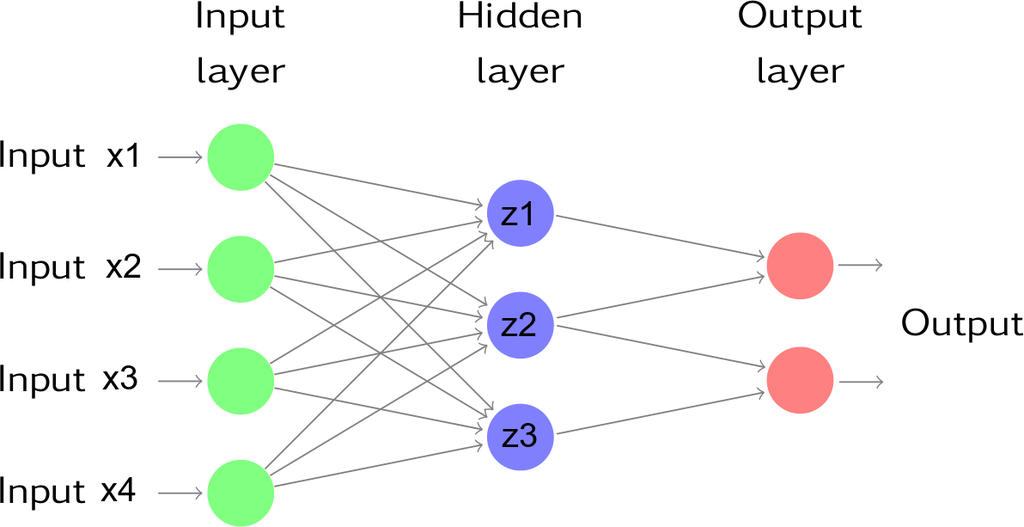

Example of simple feed-forward Neural Network

The outputs of nodes in one layer are inputs to the next layer. The inputs to each node are combined using a weighted linear combination. The result is then usually modified by a nonlinear function before being output. For example, the inputs into hidden neuron $j$ in above figure are combined to give

$z_j=b_j+\sum_{i=1}^4 w_{i,j} x_i$.

In the hidden layer, this is then modified using a nonlinear function such as a sigmoid,

$\phi(z)=\dfrac{1}{1+e^{-z}}$,

to give the input for the next layer. This allows the formula to reduce the effect of extreme input values, thus making the network more robust to outliers.

The parameters $b_1$,$b_2$,$b_3$ and $w_{1,1}, \cdots ,w_{4,3}$ are “learned” from the data.

The weights usually take random values to begin with, and are then updated using the observed data. Consequently, there is an element of randomness in the predictions produced by a neural network. Therefore, the network is usually trained several times using different random starting points, and the results are averaged.

The number of hidden layers, and the number of nodes in each hidden layer, must be specified in advance.

The R `nnet` require gives a `nnet()` function to fit a single-hidden-layer neural network to data. `nnet()` produces in output an object of class `nnet.formula` and `nnet`.

The syntax used to build a `nnet` object is very similar to the one used for (generalized) linear models:

```r
nn0 <- nnet(Status ~ Class+Gender+Age,data=titanic,size=3)
prednn <- predict(nn0)
```

The `size` parameter of above `nnet()` call specifies the number of units (neurons) in hidden layer. `prednn` contains the predictions obtained using the `nn0` model.  
As you can see, there are many analogies between `(g)lm` and `nn` models specifications.

### Regression/classification tree

```r
rt0 <- rpart(Status ~ Class+Gender+Age,data=titanic)

predrt <- predict(rt0)[,2]
```

Comparison among logistic model, neural network and regression tree

```r
titanic$predglm <- (predglm<.5) ## TRUE=Dead
titanic$prednn <- (prednn<.5)  ## TRUE=Dead
titanic$predrt <- (predrt<.5)  ## TRUE=Dead

table(titanic$Status,titanic$predglm)
```

```
##
##            FALSE TRUE
##   Died       126 1364
##   Survived   344  367
```

```r
table(titanic$Status,titanic$prednn)
```

```
##
##            FALSE TRUE
##   Died       126 1364
##   Survived   344  367
```

```r
table(titanic$Status,titanic$predrt)
```

```
##
##            FALSE TRUE
##   Died       126 1364
##   Survived   344  367
```

## Example: Ozone (GAM)

### Data description

Normal data (Extending the linear model with R)  
Ozone data from Breiman and Friedman, 1985

- `O3`: Ozone conc., ppm, at Sandbug AFB.
- `temp`: Temperature F. (max).
- `Ibh`: Inversion base height, feet
- `Pres`: Daggett pressure gradient (mm Hg)
- `Vis`: Visibility (miles)
- `Hgt`: Vandenburg 500 millibar height (m)
- `Hum`: Humidity, percent
- `Ibt`: Inversion base temperature, degrees F.
- `Wind`: Wind speed, mph

```r
data(ozone)

str(ozone)
```

```
## Classes 'tbl_df', 'tbl' and 'data.frame':    330 obs. of  9 variables:
##  $ O3  : int  3 5 5 6 4 4 6 7 4 6 ...
##  $ temp: int  40 45 54 35 45 55 41 44 54 51 ...
##  $ ibh : int  2693 590 1450 1568 2631 554 2083 2654 5000 111 ...
##  $ Pres: int  -25 -24 25 15 -33 -28 23 -2 -19 9 ...
##  $ Vis : int  250 100 60 60 100 250 120 120 120 150 ...
##  $ Hgt : int  5710 5700 5760 5720 5790 5790 5700 5700 5770 5720 ...
##  $ Hum : int  28 37 51 69 19 25 73 59 27 44 ...
##  $ ibt : num  47.7 55 57 53.8 54.1 ...
##  $ Wind: int  4 3 3 4 6 3 3 3 8 3 ...
```

```r
head(ozone)
```

```
## # A tibble: 6 x 9
##      O3  temp   ibh  Pres   Vis   Hgt   Hum   ibt  Wind
##   <int> <int> <int> <int> <int> <int> <int> <dbl> <int>
## 1     3    40  2693   -25   250  5710    28 47.66     4
## 2     5    45   590   -24   100  5700    37 55.04     3
## 3     5    54  1450    25    60  5760    51 57.02     3
## 4     6    35  1568    15    60  5720    69 53.78     4
## 5     4    45  2631   -33   100  5790    19 54.14     6
## 6     4    55   554   -28   250  5790    25 64.76     3
```

```r
ammgcv <- gam(O3 ~ s(temp)+s(ibh)+s(ibt),data=ozone)
summary(ammgcv)
```

```
##
## Family: gaussian
## Link function: identity
##
## Formula:
## O3 ~ s(temp) + s(ibh) + s(ibt)
##
## Parametric coefficients:
##             Estimate Std. Error t value Pr(>|t|)
## (Intercept)  11.7758     0.2382   49.44   <2e-16 ***
## ---
## Signif. codes:  0 '***' 0.001 '**' 0.01 '*' 0.05 '.' 0.1 ' ' 1
##
## Approximate significance of smooth terms:
##           edf Ref.df      F  p-value
## s(temp) 3.386  4.259 20.681 6.93e-16 ***
## s(ibh)  4.174  5.076  7.338 1.38e-06 ***
## s(ibt)  2.112  2.731  1.400    0.214
## ---
## Signif. codes:  0 '***' 0.001 '**' 0.01 '*' 0.05 '.' 0.1 ' ' 1
##
## R-sq.(adj) =  0.708   Deviance explained = 71.7%
## GCV = 19.346  Scale est. = 18.72     n = 330
```

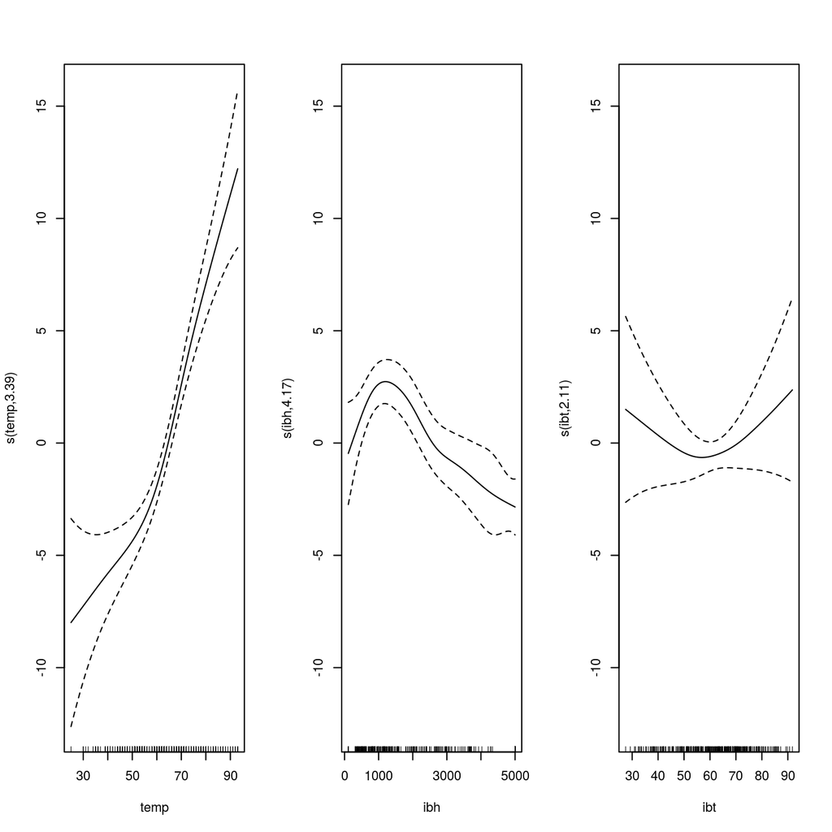

```r
op <- par(mfrow=c(1,3))
plot(ammgcv)
par(op)
```

Linear component for temp

```r
am1 <- gam(O3 ~ s(temp)+s(ibh), data=ozone)
am2 <- gam(O3 ~ temp+s(ibh), data=ozone)
anova(am2,am1,test="F")
```

```
## Analysis of Deviance Table
##
## Model 1: O3 ~ temp + s(ibh)
## Model 2: O3 ~ s(temp) + s(ibh)
##   Resid. Df Resid. Dev     Df Deviance      F    Pr(>F)
## 1    322.74       6950
## 2    319.11       6054 3.6237   895.98 13.109 3.146e-09 ***
## ---
## Signif. codes:  0 '***' 0.001 '**' 0.01 '*' 0.05 '.' 0.1 ' ' 1
```

Adding interaction

```r
amint <- gam(O3 ~ s(temp, ibh)+s(ibt), data=ozone)
summary(amint)
```

```
##
## Family: gaussian
## Link function: identity
##
## Formula:
## O3 ~ s(temp, ibh) + s(ibt)
##
## Parametric coefficients:
##             Estimate Std. Error t value Pr(>|t|)
## (Intercept)  11.7758     0.2409   48.88   <2e-16 ***
## ---
## Signif. codes:  0 '***' 0.001 '**' 0.01 '*' 0.05 '.' 0.1 ' ' 1
##
## Approximate significance of smooth terms:
##               edf Ref.df      F  p-value
## s(temp,ibh) 6.346  8.040 14.860  < 2e-16 ***
## s(ibt)      2.917  3.679  9.805 6.52e-07 ***
## ---
## Signif. codes:  0 '***' 0.001 '**' 0.01 '*' 0.05 '.' 0.1 ' ' 1
##
## R-sq.(adj) =  0.702   Deviance explained =   71%
## GCV = 19.767  Scale est. = 19.152    n = 330
```

```r
anova(ammgcv,amint,test="F")
```

```
## Analysis of Deviance Table
##
## Model 1: O3 ~ s(temp) + s(ibh) + s(ibt)
## Model 2: O3 ~ s(temp, ibh) + s(ibt)
##   Resid. Df Resid. Dev       Df Deviance      F  Pr(>F)
## 1    316.93     5977.9
## 2    317.28     6123.6 -0.34665  -145.66 22.445 0.00113 **
## ---
## Signif. codes:  0 '***' 0.001 '**' 0.01 '*' 0.05 '.' 0.1 ' ' 1
```

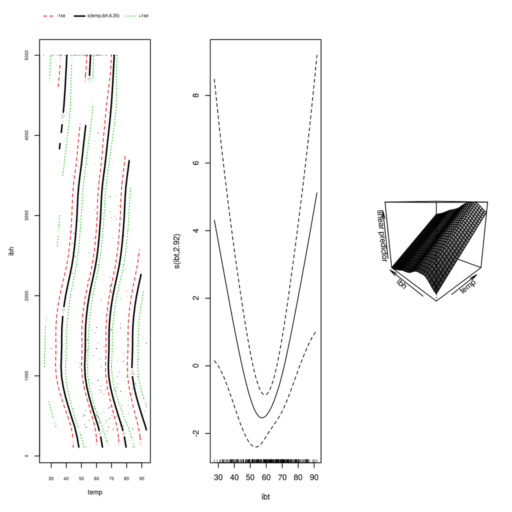

```r
op=par(mfrow=c(1,3))
plot(amint)
vis.gam(amint,theta=-45,color="gray")
par(op)
```

Use the simpler model to produce residuals analysis

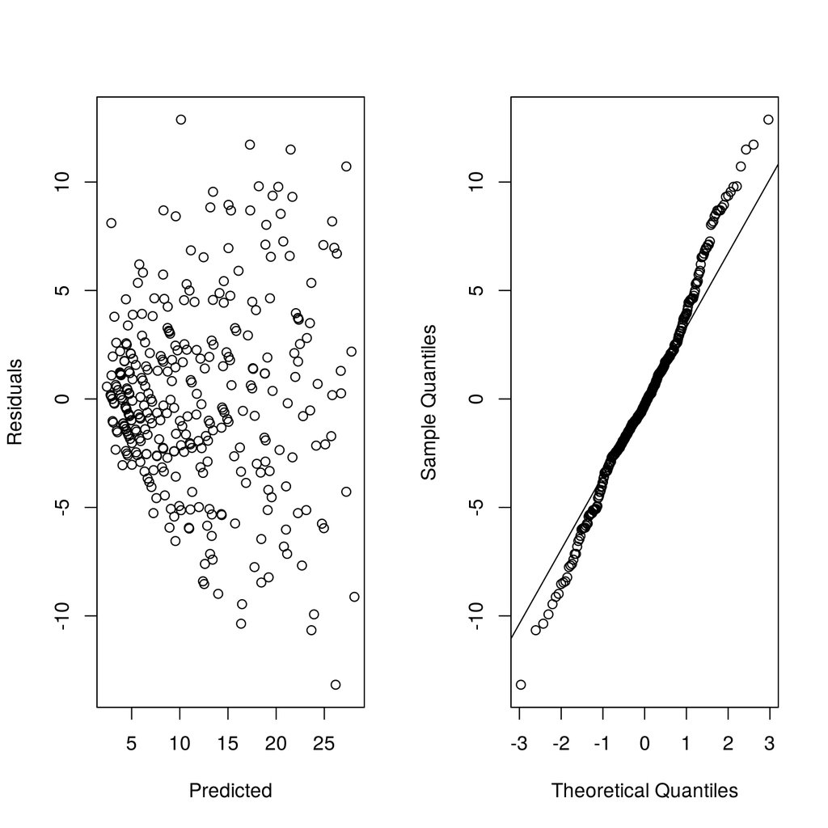

```r
op=par(mfrow=c(1,2))
plot (predict (ammgcv), residuals
      (ammgcv),xlab="Predicted",ylab="Residuals")
qqnorm (residuals (ammgcv), main="")
qqline(residuals (ammgcv))
par(op)
```

Try another model using Gamma distribution

```r
ammgcv <- gam(O3 ~ s(temp)+s(ibh)+s(ibt),data=ozone,family=Gamma(link="identity"))
summary(ammgcv)
```

```
##
## Family: Gamma
## Link function: identity
##
## Formula:
## O3 ~ s(temp) + s(ibh) + s(ibt)
##
## Parametric coefficients:
##             Estimate Std. Error t value Pr(>|t|)
## (Intercept)   11.657      0.288   40.47   <2e-16 ***
## ---
## Signif. codes:  0 '***' 0.001 '**' 0.01 '*' 0.05 '.' 0.1 ' ' 1
##
## Approximate significance of smooth terms:
##           edf Ref.df      F  p-value
## s(temp) 3.879  4.829 32.891  < 2e-16 ***
## s(ibh)  5.041  6.071 10.020 2.66e-10 ***
## s(ibt)  1.000  1.000  3.315   0.0695 .
## ---
## Signif. codes:  0 '***' 0.001 '**' 0.01 '*' 0.05 '.' 0.1 ' ' 1
##
## R-sq.(adj) =  0.701   Deviance explained = 69.1%
## GCV = 0.16723  Scale est. = 0.15697   n = 330
```

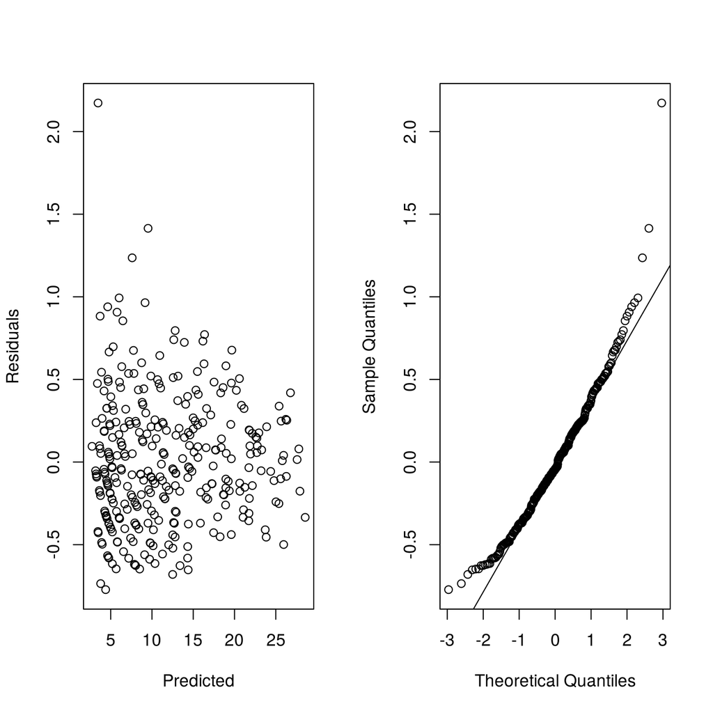

```r
op=par(mfrow=c(1,2))
plot (predict (ammgcv), residuals
      (ammgcv,type="pearson"),xlab="Predicted",ylab="Residuals")
qqnorm (residuals (ammgcv,type="pearson"), main="")
qqline(residuals (ammgcv,type="pearson"))
par(op)
```